# Notes: ‘Hands-On Machine Learning with R’

Steven Marcel Bißantz

2023-03-25

**Disclaimer**: The script contains my extended summary of the book “Hands-On Machine Learning with R” by Bradley Boehmke & Brandon Greenwell. That is, most of the information you read here is not mine. Nevertheless, I have also reworded sections and incorporated my own thoughts. For a clear delimitation, please read the original text.

## Chapter 1: Introduction

**Machine learning**: A framework for developing algorithmic models that use information (e.g., data) to approximate or extract functional relationships between variables.

**Learning**: The process by which the model integrates information (e.g., data) to optimize the algorithmic steps (e.g., parameters, weights) and thereby improve performance on a given task (e.g., prediction for unseen data).

**Loss function**: An objective function that measures the discrepancy or error between a model output (e.g., parameters, predictions) and a target - for *a single* data instance.

*Example* (prediction loss): $L_{\text{sq}}(\hat y, y) = (\hat y- y)^2$

**Cost function** (aka. empirical risk): A function that measures the discrepancy or error between a model output (e.g., parameters, predictions) and a target - across (all) data instances.

**Example** (Cost as the mean loss): $C_(f, \mathcal D) = \frac{1}{n} \sum_{i=1}^n L(\hat{y}_i, y_i)$

*Example* (prediction loss): $L_{\text{sq}}(\hat{\mathbf{y}}, \mathbf y) = \lVert \hat{\mathbf y} - \mathbf y \rVert^2$

**Objective function**: A function that is *optimized* during model training (i.e., learning) to achieve a specific goal.

**Cost function**: An objective function that measures the discrepancy or error between a model output (e.g., parameters, predictions) and a target.

*Note*: This is what actually gets minimized during training.

*Example* The loss function, on the other hand, is a specific type of objective function that measures the discrepancy between the predicted and actual values.

*Instances*: There are different categories for loss functions, e.g. estimation loss functions $L(\theta, \hat{\theta})$, or, more generally, prediction loss functions $L(y,\hat{y})$.

*Important*: Cost function or Utility function

*Example*: The Kullback-Leibler Divergence minimizes the (info) distance between our model distribution $\mathbf{q}$ and the true frequency distribution of events $\mathbf{p}$

*Note*: This updating-process is sometimes called “learning”, and thus the algorithm a learner.

*Example*: SGD finds the minimum of a discrepancy function (aka., loss, utility, or cost function). This can beautifully be visualized.

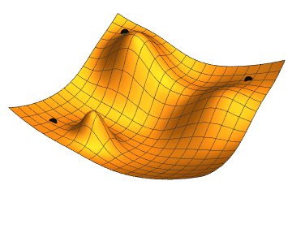

Figure: An intuitive visualization of the stochastic gradient descent method. The picture is taken from: https://commons.wikimedia.org/wiki/File:Gradient_descent.gif

In machine learning, the dataset is usually split into three parts: training data, validation data, and test data.

The training data is used to train the model, i.e., to learn the model parameters. The validation data is used to evaluate the model during the training process and to tune the hyperparameters of the model, such as the learning rate or the number of hidden layers in a neural network.

Training set: This is the data used to train the model. During this stage, the model learns the patterns and relationships in the data, and updates its parameters to minimize the training loss. The training set is the only data that the model has seen during training.

Validation set: This is the data used to tune the hyperparameters of the model. Hyperparameters are the settings that control the learning process, such as the learning rate, batch size, and number of hidden layers. The model’s performance on the validation set is used to determine the optimal hyperparameters that minimize the validation loss.

The test data is used to evaluate the final performance of the trained model after the model has been fully trained and tuned. The test data is usually kept separate from the training and validation data, and is only used once to test the final performance of the model. The test data is used to simulate how the model will perform on new, unseen data, and to estimate the generalization error of the model.

Testing set: This is the data used to evaluate the performance of the final model. The testing set is separate from the training and validation sets, and the model has not seen this data during training or validation. The testing set provides an unbiased estimate of the model’s performance on new, unseen data.

In summary, the validation data is used during the training process to tune the hyperparameters, while the test data is used to evaluate the final performance of the trained model and estimate its generalization error.

The training set is used to fit the model, the validation set is used to tune the model’s hyperparameters, and the testing set is used to evaluate the model’s performance on new, unseen data. The validation set is used during the model selection process, while the testing set is reserved for a final evaluation of the chosen model.

In some cases, cross-validation techniques can also be used to further split the data and obtain better estimates of the model’s performance.

### “Mere” predictions” vs. “causal predictions”

*In a nutshell*: Mere predictions aim to accurately predict outcomes, causal predictions aim to estimate the effects of interventions and understand the causal relationships between input features and the outcome variable (see: DAGs).

“Mere” predictions focus on accurately predicting the outcome of a target variable based on input features without necessarily considering the underlying causes or mechanisms that drive the relationship between them.

*Example*: This type of prediction is commonly used in applications such as recommender systems, image classification, and natural language processing.

**Causal predictions**: …on the other hand, aim to estimate the effect of an intervention or treatment on a target variable by accounting for the causal relationships between the input features and the outcome variable. This requires a deeper understanding of the underlying causal mechanisms and potential confounding factors that can impact the outcome.

*Example*: Causal inference techniques such as randomized controlled trials, propensity score matching, instrumental variable analysis and, often forgoten, *do-calculus* given observational data, are commonly used to estimate causal effects in various domains such as healthcare, social sciences, and economics.

#### Machine learning paradigms

We could classify ML models according to the amount of supervision needed during training. However, do not forget reinforcement learning:

1. Supervised learning (~predictive models)
2. Unsupervised learning (–descriptive models)
3. Reinforcement Learning

**Supervision**: …means, to provide the algorithm with predefined “labeled” training data. “No supervision” implies, the algorithm needs to do the assignment of the labels itself.

**Labelling**: …refers to the process of assigning a specific category or value to each data point (e.g., based on experts opinion, or a specific criterion)

*Example*: Experts diagnosed (i.e. “labeled”) 500 patients with Major Depression Disorder (MDD): $y$. Now we can train an algorithm based on these data, $\mathcal{D}_{train}:\{X,y\}_{i=1}^{n_{train}}$, together with patient characteristics, $X: f(X) = y$. Then we can use $f$, the learner, to make predictions for new, unseen patients, for example, $i$ in $\mathcal{D}_{test}:\{X,y\}_{i=1}^{n_{test}}$.

#### Data quality & Validity

I have seen few authors discussing this point: *Do always critically reflect on the quality of your labels*. In unsupervised machine learning we often do this, because we want to check the quality of the machine predictions. In supervised machine learning the labels are preassigned. Still, we must check the validity of the scores assigned by experts or criteria. Do they make sense or are they high quality?

The quality of the approximation ($y = f(X)$) is only of importance if $y$ is valid. If $y$ is trash then we get “a good approximation – but of trash”. *Garbage in garbage out* it is that simple.

### Supervised learning (~predictive models)

**Supervised machine learning**: A function approximation approach that aims to emulate a (unknown) mapping function from input data to labeled output values, with the goal of accurately predicting the labels for new, unseen data.

**Supervised learning**: Develop an algorithm or predictive model that uses labeled data $D:\{X,y\}_{i=1}^n$ to produces an accurate (e.g., non- or piecewise linear) approximation of the mapping function “$f$”: $y=f(X)$ – and make accurate predictions for future values of $\tilde{y}$ based on a set of features ($X$). (*Note*: The labels are often assigned based on a criterion or expert knowledge)

**Why is supervised learning “supervised”?**

Because the *training* data ($\mathcal{D}_{train}:\{X,y\}_{i=1}^{n_{train}}$) you feed the algorithm includes the target values ($y$). Consequently, the solutions can be used to help supervise the training process to find the optimal algorithm parameters.

**Underlying function assumption**: Given a dataset comprised of inputs and outputs $D:\{X,y\}_{i=1}^n$, we assume that there is an unknown underlying function that is consistent in mapping inputs to outputs in the target domain and resulted in the dataset. We then use supervised learning algorithms to approximate this function.

*Open Question*: Does it need to be a function, or are also relations possible? e.g. $y = x^2$?. I think relations are not possible, since there is no unique element in the codomain or range for each element in the domain.

#### The two problems in supervised learning

1. Regression problem
2. Classification problem

#### Regression problem

**Regression problem**: …means the objective of our supervised learning is to predict a numeric outcome that falls on a continuum $(-\infty, \infty)$.

$$y_{\in \mathbb{R}} = f(X_{\in
\mathbb{R}})$$

*Example*: Predict height based on persons characteristics, like sex.

#### Classification problem

**Clasification problem**: …means the objective of our supervised learning is to predict a categorical outcome (i.e., a binary or multinomial response measure)

*Example*: Classify customer reviews from 0 to 5 (multinomial) or “like”, “don’t like” (binary).

*Important*: In ML often ordinal responses are modeled as categorical processes and thus with a multinomial distribution.

**Classification problems are kind of regression problems**: Every classification is a (logistic) regression problem. In a general regression problem can be formalized as $y_{\in \mathbb{R}} = f(X_{\in \mathbb{R}})$. In a classification problem the situation is as follows: $y_{\in [0,1]} = f(X_{\in \mathbb{R}})$. *Note that $[0,1]$ is a subset of $\mathbb{R}^+$*. The problem is thus: $y_{\in [0,1]\subset \mathbb{R}^+} = f(X_{\in \mathbb{R}})$. What about the categories? In this binary case, the labels for the categories are assigned ex post according to 0/1 assignment rule.

**0/1 Assignment rule**: If we predict the probability of a class ($P(X=1)$); by default, the class with the highest predicted probability becomes the predicted class:

$$k = \begin{cases} 0 &
\Leftrightarrow p < 0.5 \\ 1 & \Leftrightarrow p \geq
0.5 \end{cases}$$

### Unsupervised learning (~descriptive models)

**Unsupervised learning**: …develop algorithms that uses unlabeled information to discover functional relationships between variables (rows, columns).

In essence, unsupervised learning is concerned with identifying groups in a data set. The groups may be defined by the rows (i.e., clustering) or the columns (i.e., dimension reduction); however, the motive in each case is quite different.

**How is unsupervised learning related to function approximation?** Think of unsupervised learning as an emulator for a (unknown) function that maps input data to some meaningful representation without any labeled output.

**Underlying function assumption**: Given a dataset: $D:\{Z_i\}$, we assume that there is an unknown functional relationship between the variables (rows, columns). We then use unsupervised learning algorithms to discover this function.

#### The two topics in unsupervised learning:

1. Clustering (~ rows in the data set)
2. Dimension reduction (~ columns in the data set)

#### Clustering

**Clustering**: …means to use the observed variables (i.e., columns) to segment observations (i.e., rows) into similar (more homogeneous) groups.

*Example*: “Market segmentation” – where we divide consumers into different homogeneous groups.

#### Dimension reduction

**Dimension reduction**: …means to reduce the number of variables (i.e. columns) in a data set.

*Example*: Factor analysis – identify the underlying dimensions (factors) that explain patterns of correlations among multiple variables (items).

$$R^* = \Lambda \Phi \Lambda +
\Psi$$

##### Full compression vs. meaningful compression

Full – orthogonal – compression versus meaningful compression:

**Full compression**: If we have a regression model which tend to break with highly correlated variables, or have a data set where the predictors are so rich that we can’t process them with our machines, we can use PCA to compress the data set fully, i.e. reduce it with minimal loss in recovery to the smallest amount of uncorrelated variables – the principal components.

**Meaningful compression**: If we want to understand or model the structural relationships between variables with more flexibility (i.e. $\Phi$) we can try to find factors that first and foremost make sense.

#### Downstream supervised learning

**Downstream supervised learning**: The outputs of unsupervised learning models can be used as inputs to downstream supervised learning models.

*Example*: Using a reduced feature set of a PCA and input it to downstream supervised learning models (e.g., principal component regression).

##### Problems: Quality assessment in supervised and unsupervised learning

With unsupervised learning it seems harder to assess the quality of the results, because we don’t know the true answer — the problem is unsupervised!

With predictive models and supervised learning algorithms (i.e., linear regression), it is possible to check our work by seeing how well our model predicts the response Y on observations not used in fitting the model.

However, this does not safeguard against the quality check for the labels. If those are trash, then good predictions are meaningless.

### Reinforcement learning

**Reinforcement learning**: …is a training method based on rewarding desired behaviors and/or punishing undesired ones. In general, a reinforcement learning agent is able to perceive and interpret its environment, take actions and learn through trial and error.

## Chapter 2: Modeling Process

```r
# Helper packages
pkgs <- c("rsample", # Resampling procedures
          "caret",   # Resampling and model training
          "h20")     # Resampling and model training

# lapply(pkgs, library, character.only=TRUE)

# h2o
h2o::h2o.no_progress() # Avoid the progress bars in the output
h2o::h2o.init()
```

[output not shown]

```r
?AmesHousing::ames_raw

# Ames housing data
ames <- AmesHousing::make_ames()

# Coerce to a h2o frame
ames_h2o <- h2o::as.h2o(ames)

# Job attrition data
# Note: the data are now in the modeldata package
churn <- modeldata::attrition
str(churn)
```

```
## 'data.frame':    1470 obs. of  31 variables:
##  $ Age                     : int  41 49 37 33 27 32 59 30 38 36 ...
##  $ Attrition               : Factor w/ 2 levels "No","Yes": 2 1 2 1 1 1 1 1 1 1 ...
##  $ BusinessTravel          : Factor w/ 3 levels "Non-Travel","Travel_Frequently",..: 3 2 3 2 3 2 3 3 2 3 ...
##  $ DailyRate               : int  1102 279 1373 1392 591 1005 1324 1358 216 1299 ...
##  $ Department              : Factor w/ 3 levels "Human_Resources",..: 3 2 2 2 2 2 2 2 2 2 ...
##  $ DistanceFromHome        : int  1 8 2 3 2 2 3 24 23 27 ...
##  $ Education               : Ord.factor w/ 5 levels "Below_College"<..: 2 1 2 4 1 2 3 1 3 3 ...
##  $ EducationField          : Factor w/ 6 levels "Human_Resources",..: 2 2 5 2 4 2 4 2 2 4 ...
##  $ EnvironmentSatisfaction : Ord.factor w/ 4 levels "Low"<"Medium"<..: 2 3 4 4 1 4 3 4 4 3 ...
##  $ Gender                  : Factor w/ 2 levels "Female","Male": 1 2 2 1 2 2 1 2 2 2 ...
##  $ HourlyRate              : int  94 61 92 56 40 79 81 67 44 94 ...
##  $ JobInvolvement          : Ord.factor w/ 4 levels "Low"<"Medium"<..: 3 2 2 3 3 3 4 3 2 3 ...
##  $ JobLevel                : int  2 2 1 1 1 1 1 1 3 2 ...
##  $ JobRole                 : Factor w/ 9 levels "Healthcare_Representative",..: 8 7 3 7 3 3 3 3 5 1 ...
```

[output cut: 17 more lines]

```r
# Coerce ordered factors
unorder_if <- function(x) {
  # Have to call 'return()' explicitally
  ifelse(is.ordered(x), factor(x, ordered = FALSE), return(x))
  }
# Trick: Use '[]' to keep the data frame structure
churn[] <- lapply(churn, unorder_if)
str(churn)
```

```
## 'data.frame':    1470 obs. of  31 variables:
##  $ Age                     : int  41 49 37 33 27 32 59 30 38 36 ...
##  $ Attrition               : Factor w/ 2 levels "No","Yes": 2 1 2 1 1 1 1 1 1 1 ...
##  $ BusinessTravel          : Factor w/ 3 levels "Non-Travel","Travel_Frequently",..: 3 2 3 2 3 2 3 3 2 3 ...
##  $ DailyRate               : int  1102 279 1373 1392 591 1005 1324 1358 216 1299 ...
##  $ Department              : Factor w/ 3 levels "Human_Resources",..: 3 2 2 2 2 2 2 2 2 2 ...
##  $ DistanceFromHome        : int  1 8 2 3 2 2 3 24 23 27 ...
##  $ Education               : int  2 2 2 2 2 2 2 2 2 2 ...
##  $ EducationField          : Factor w/ 6 levels "Human_Resources",..: 2 2 5 2 4 2 4 2 2 4 ...
##  $ EnvironmentSatisfaction : int  2 2 2 2 2 2 2 2 2 2 ...
##  $ Gender                  : Factor w/ 2 levels "Female","Male": 1 2 2 1 2 2 1 2 2 2 ...
##  $ HourlyRate              : int  94 61 92 56 40 79 81 67 44 94 ...
##  $ JobInvolvement          : int  3 3 3 3 3 3 3 3 3 3 ...
##  $ JobLevel                : int  2 2 1 1 1 1 1 1 3 2 ...
##  $ JobRole                 : Factor w/ 9 levels "Healthcare_Representative",..: 8 7 3 7 3 3 3 3 5 1 ...
```

[output cut: 17 more lines]

**No free lunch theorem** (Wolpert 1996): “There is no single model that can outperform all other algorithms on all possible tasks or problems.”

*Implication 1*: Participate in an iterative, playful and explorative model building process. Never rely on a single “best” algorithm for all problems. (see also: Stacking)

*Implication 2*: Approaching ML modeling correctly means approaching it strategically by * …spending our data wisely on learning and validation procedures, * …properly pre-processing the feature and target variables, * …minimizing data leakage, * …tuning hyperparameters, and * …assessing model performance

**Generalizability**: The ability of an algorithm to accurately predict future outcomes, rather than just fitting well to past data, e.g. the sample.

### Data Splitting

To provide an accurate understanding of the generalizability of our final optimal model, we can split our data into *training* and *test data sets*:

- **Training set**: The data we use to develop feature sets, train the algorithm, tune hyperparameters, and compare models.
- **Test set**: The data that we given a final model use to estimate an unbiased assessment of the model’s performance on unseen data, i.e. its *generalization error*.

**Generalization error**: The difference between a model’s performance on the training data and its performance on new, unseen data, like the validation set.

#### Rough guidelines for the split

**N: small-medium**

- Spending too much in training (e.g., >80%) won’t allow us to get a good assessment of predictive performance. We may find a model that fits the training data very well, but is not generalizable (*overfitting*).
- Sometimes too much spent in testing (>40%) won’t allow us to get a good assessment of model parameters.

e.g. 60% (training)-40% (testing), 70%-30%, or 80%-20%

**N: big (100K)**

Small gains with additional data as compared to smaller sample sizes.

- $p \leq n$: Use a smaller training sample to increase computation speed (e.g., models built on larger training sets often take longer to score new data sets in production)
- $p \geq n$: Keep the samples sizes large, because the information is needed to identify consistent signals in the features.

#### Common splitting schemes:

1. Simple random sampling
2. Stratified sampling

#### Simple random sampling splitting

**Simple random sampling splitting**: Take a simple random sample from the data – with the desired probability

**Simple random sampling**: A sampling method where each member of the population has an equal and independent chance of being selected for the sample. This means that every possible sample of the desired size has an equal probability of being selected.

*Procedure*: Assing each member of the population a unique identification number, and use a random number generator to select the required number of samples.

*Benefits*: …considered to be unbiased and used to minimize the risk of selection bias, where certain subgroups of the population are overrepresented or underrepresented in the sample.

*Problem*: Does not control for any data attributes, such as the distribution of your response variable ($y$).

*Usecases*: Classification and regression problems when we have a sufficient sample size. In classification problems especially when there is a good balance between the classes.

#### Simple random sampling

Use `base` and no additional packages.

```r
# Reproduceable results
set.seed(123)
# Number of rows
n_rows <- nrow(ames)
# Row index
row_index <- seq(n_rows)
# Index for the training cases
train_index <- sample(row_index, size = round(n_rows) * 0.7, replace = FALSE)
# Training set
train <- ames[train_index,] ; cat("Training set: ", dim(train), "\n")
```

```
## Training set:  2051 81
```

```r
# Testing set
test <- ames[-train_index,] ; cat("Testing set: ", dim(test), "\n")
```

```
## Testing set:  879 81
```

```r
# Plausibility check
cat("Split: ", dim(train)[1] / n_rows * 100, "/", dim(test)[1] / n_rows * 100)
```

```
## Split:  70 / 30
```

Use the `caret` package.

```r
# Reproduceable results
set.seed(123)
# Index for the elements in the training set
train_index <- caret::createDataPartition(ames$Sale_Price, p = 0.7,
                               # Matrix instead of a list as output
                               list = FALSE)
# Training set
train <- ames[train_index,] ; cat("Training set: ", dim(train), "\n")
```

```
## Training set:  2053 81
```

```r
# Testing set
test <- ames[-train_index,] ; cat("Testing set: ", dim(test), "\n")
```

```
## Testing set:  877 81
```

```r
# Plausibility check
cat("Split: ", dim(train)[1] / n_rows * 100, "/", dim(test)[1] / n_rows * 100)
```

```
## Split:  70.06826 / 29.93174
```

Use the `rsample` package.

```r
# Reproduceable results
set.seed(123)
split  <- rsample::initial_split(ames, prop = 0.7)
# Training set
train <- rsample::training(split)
# Testing set
test <- rsample::testing(split)
# Plausibility check
cat("Split: ", dim(train)[1] / n_rows * 100, "/", dim(test)[1] / n_rows * 100)
```

```
## Split:  70 / 30
```

#### Stratified sampling splitting

**Stratified sampling splitting**: Take a stratified sample from the data – with the desired probability.

**Stratified sampling**: A sampling method where the population is divided into subgroups (aka., *strata*), and then a random sample is taken from each subgroup (aka. *stratum*) in proportion to their size or importance.

*Procedure*: Segment $y$ into classes (discrete $y$) or quantiles (continuous $y$) and randomly sample from each.

*Benefits*: Allows to explicitly control the sampling so that our training and test sets have similar Y distributions

*Usecases*: Classification and regression problems

1. *Classification problems*: When $y$ is severely imbalanced (e.g., 90% “Yes” and 10% “No”). See also: Class Imbalances
2. *Regression problems*: With small sample size and where y deviates strongly from normality (i.e., positively skewed like Sale_Price).

```r
# Data with class imbalances
table(churn$Attrition) |> prop.table()
```

```
##
##        No       Yes
## 0.8387755 0.1612245
```

Stratified sampling using the `rsample` package.

```r
# Reproduceable results
set.seed(123)
#  Split the data into training and testing sets
split_strat <- rsample::initial_split(churn, prop = 0.7, strata = "Attrition")
train <- rsample::training(split_strat)
test <- rsample::testing(split_strat)
# Plausibility check
cat("Training set", table(train$Attrition) |> prop.table())
```

```
## Training set 0.8394942 0.1605058
```

```r
cat("Testing set", table(test$Attrition) |> prop.table())
```

```
## Testing set 0.8371041 0.1628959
```

#### Class imbalances

Imbalanced data can have a significant impact on model predictions and performance (Kuhn and Johnson 2013).

#### Categorization:

1. Up-sampling
2. Down-sampling
3. Over-Under-Sampling

#### Down sampling

**Down sampling**: Balance the dataset by reducing the size of the abundant class(es) to match the frequencies in the least prevalent class.

*Important*: By keeping all samples in the rare class and randomly selecting an equal number of samples in the abundant class, a balanced new dataset can be retrieved for further modeling. Furthermore, the reduced sample size reduces the computation burden imposed by further steps in the ML process.

**When should we use down-sampling**? If there are enough data.

The option is implemented in the `caret`package. Use the `sampling` argument with the option `down`.

```r
?caret::trainControl
```